# TateyamaForestZoneShift

# FIGURE 9 | Changes in the cumulative ratio of dead standing *A. mariesii* trees in the Ecotone plot in 2000 and the estimated frequency of death.

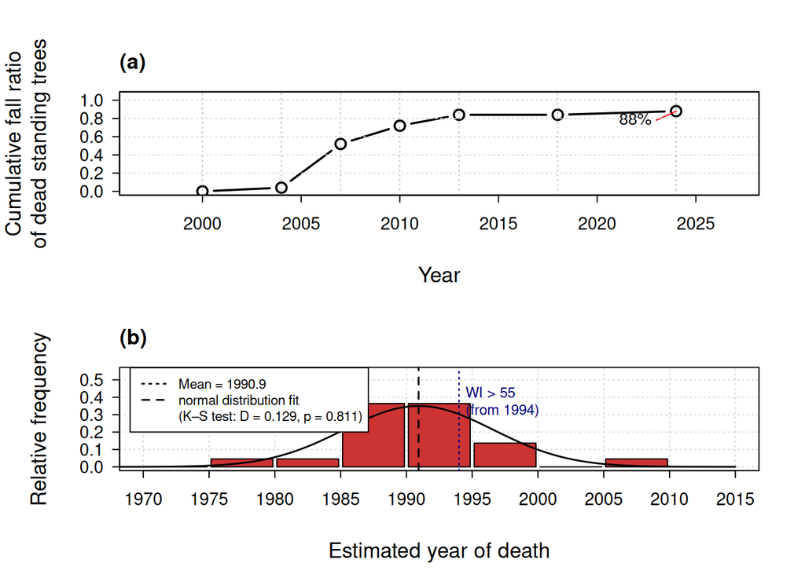

```r
Fig12_revised ()
```

# FIGURE 10 | Changes in cumulative mortality ratio of *Abies mariesii* in each survey plot over time.

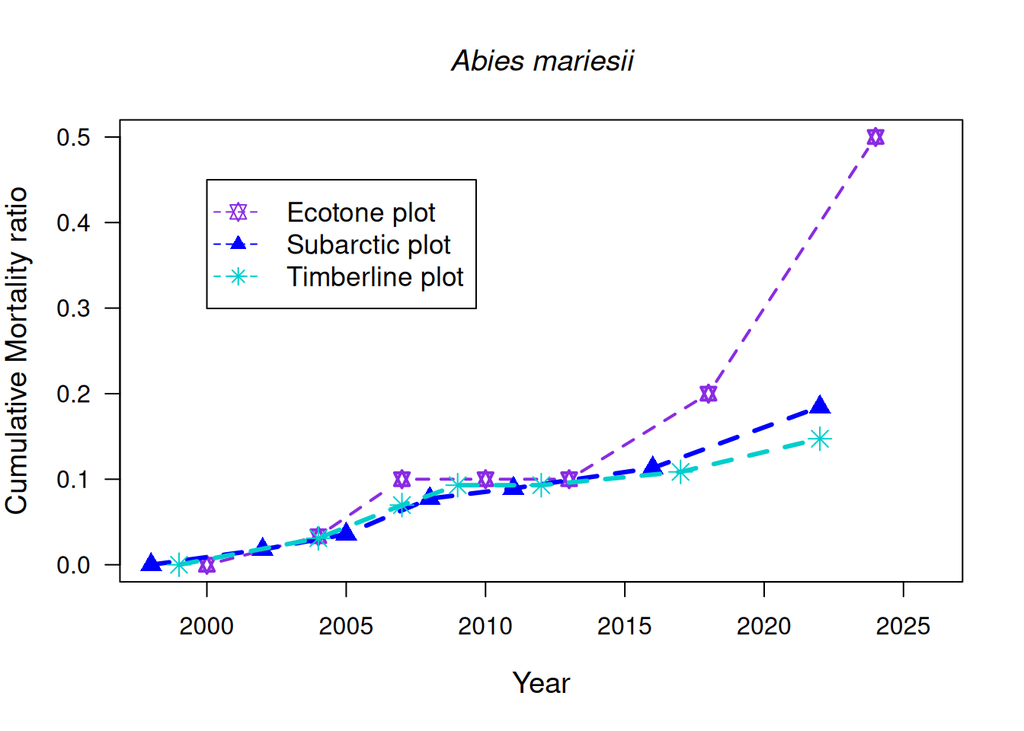

```r
Fig_Abies_death_ratio()
```

```r
res1 <- statistics_cor_WI_AbiesCumulativeMortality(s)
```

```
## Pearson correlation: WI vs. cumulative mortality
```

```r
res1
```

| plot | r | p | n |
| --- | --- | --- | --- |
| Kaminokodaira | 0.8446427 | 0.01677438 | 7 |
| Matsuotoge | -0.4304284 | 0.33504659 | 7 |
| Kagamiishi | -0.6352663 | 0.12525620 | 7 |
| Pooled | 0.4086731 | 0.06586100 | 21 |

## ANCOVA: cumulative mortality ratio ~ year * plot

```r
res2 <- statistics_ANCOVA_Abies_CumulativeDeathRatio_year_plot(s)
```

```
## ANCOVA: cumulative mortality ~ year * plot
```

```
##
## Call:
## lm(formula = death_ratio ~ year * plot, data = s$death_data)
##
## Residuals:
##      Min       1Q   Median       3Q      Max
## -0.08700 -0.01029 -0.00093  0.01097  0.11083
##
## Coefficients:
##                       Estimate Std. Error t value Pr(>|t|)
## (Intercept)         -36.809434   4.595067  -8.011 8.47e-07 ***
## year                  0.018379   0.002285   8.043 8.06e-07 ***
## plotMatsuotoge       21.662900   6.495176   3.335  0.00452 **
## plotKagamiishi       24.601622   6.694107   3.675  0.00225 **
## year:plotMatsuotoge  -0.010802   0.003232  -3.343  0.00445 **
## year:plotKagamiishi  -0.012267   0.003330  -3.684  0.00221 **
## ---
## Signif. codes:  0 '***' 0.001 '**' 0.01 '*' 0.05 '.' 0.1 ' ' 1
##
## Residual standard error: 0.04621 on 15 degrees of freedom
## Multiple R-squared:  0.8616, Adjusted R-squared:  0.8154
## F-statistic: 18.67 on 5 and 15 DF,  p-value: 5.798e-06
##
##
## --- Slope of each plot ---
##   Kaminokodaira        0.018379 /yr
##   Matsuotoge           0.007577 /yr
##   Kagamiishi           0.006112 /yr
##
## --- Pairwise slope comparisons (death_ratio ~ year) ---
##                    comparison slope_ref slope_other slope_diff t_value p_value
## 1 Kaminokodaira vs Matsuotoge   0.01838     0.00758   -0.01080  -3.343  0.0045
## 2 Kaminokodaira vs Kagamiishi   0.01838     0.00611   -0.01227  -3.684  0.0022
## 3    Matsuotoge vs Kagamiishi   0.00758     0.00611   -0.00146  -0.440  0.6663
```

```r
res2$pairwise
```

| comparison | slope_ref | slope_other | slope_diff | t_value | p_value |
| --- | --- | --- | --- | --- | --- |
| Kaminokodaira vs Matsuotoge | 0.01838 | 0.00758 | -0.01080 | -3.343 | 0.0045 |
| Kaminokodaira vs Kagamiishi | 0.01838 | 0.00611 | -0.01227 | -3.684 | 0.0022 |
| Matsuotoge vs Kagamiishi | 0.00758 | 0.00611 | -0.00146 | -0.440 | 0.6663 |

# FIGURE 11 | Relationships between the warmth index (WI) and (a) basal area ratio and (b) cumulative mortality ratio of *Abies mariesii* in the Timberline, Subarctic, and Ecotone plots.

```r
Abies
```

|  | plot | year | BAratio | mortality | WI |
| --- | --- | --- | --- | --- | --- |
| 36 | Kaminokodaira | 2000 | 1.0000000 | 0.00000000 | 52.92710 |
| 40 | Kaminokodaira | 2004 | 1.0023957 | 0.03333333 | 54.39599 |
| 43 | Kaminokodaira | 2007 | 0.9006119 | 0.10000000 | 55.49766 |
| 46 | Kaminokodaira | 2010 | 0.9314482 | 0.10000000 | 56.59932 |
| 49 | Kaminokodaira | 2013 | 0.9520498 | 0.10000000 | 57.70099 |
| 54 | Kaminokodaira | 2018 | 0.9358946 | 0.20000000 | 59.53710 |
| 60 | Kaminokodaira | 2024 | 0.6415239 | 0.50000000 | 61.74043 |
| 34 | Matsuotoge | 1998 | 1.0000000 | 0.00000000 | 34.80163 |
| 38 | Matsuotoge | 2002 | 1.0101878 | 0.01785714 | 36.03244 |
| 41 | Matsuotoge | 2005 | 1.0088253 | 0.03571429 | 36.95554 |

[output cut: 11 more lines]

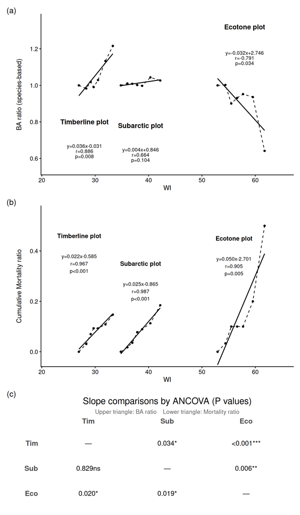

```r
res <- Fig_Abies_wi_ba_mortality()
```

```r
res
```

```
## $regression_ba
##              plot                          reg_label    x y_name y_reg
## 1    Ecotone plot y=-0.032x+2.746\nr=-0.791\np=0.034 58.0   1.32  1.15
## 2  Subarctic plot   y=0.004x+0.846\nr=0.664\np=0.104 38.5   0.78  0.62
## 3 Timberline plot   y=0.036x-0.031\nr=0.886\np=0.008 28.0   0.80  0.64
##
## $regression_mortality
##              plot                        reg_label    x y_name y_reg
## 1    Ecotone plot y=0.050x-2.701\nr=0.905\np=0.005 56.0   0.45  0.34
## 2  Subarctic plot y=0.025x-0.865\nr=0.987\np<0.001 38.5   0.35  0.24
## 3 Timberline plot y=0.022x-0.585\nr=0.967\np<0.001 27.0   0.46  0.35
##
## $BAratio_ancova
## $BAratio_ancova$pw
##                          comparison slope_ref slope_other slope_diff t_value
## 1 Timberline plot vs Subarctic plot   0.03616     0.00436   -0.03180  -2.332
## 2   Timberline plot vs Ecotone plot   0.03616    -0.03228   -0.06844  -5.363
## 3    Subarctic plot vs Ecotone plot   0.00436    -0.03228   -0.03664  -3.184
##   p_value
## 1  0.0341
## 2  0.0001
## 3  0.0062
##
## $BAratio_ancova$mat
##                 Timberline plot Subarctic plot Ecotone plot
## Timberline plot "—"             "0.034*"       "<0.001***"
## Subarctic plot  "0.034*"        "—"            "0.006**"
## Ecotone plot    "<0.001***"     "0.006**"      "—"
##
##
## $mortality_ancova
## $mortality_ancova$pw
##                          comparison slope_ref slope_other slope_diff t_value
## 1 Timberline plot vs Subarctic plot   0.02211     0.02462    0.00252   0.219
## 2   Timberline plot vs Ecotone plot   0.02211     0.05005    0.02794   2.601
## 3    Subarctic plot vs Ecotone plot   0.02462     0.05005    0.02542   2.624
##   p_value
## 1  0.8294
## 2  0.0201
## 3  0.0192
##
## $mortality_ancova$mat
##                 Timberline plot Subarctic plot Ecotone plot
## Timberline plot "—"             "0.829ns"      "0.020*"
## Subarctic plot  "0.829ns"       "—"            "0.019*"
## Ecotone plot    "0.020*"        "0.019*"       "—"
```

# *Supporting Information to the paper*

## FIGUER S1 | Changes in the maximum snow depth for each plot over time.

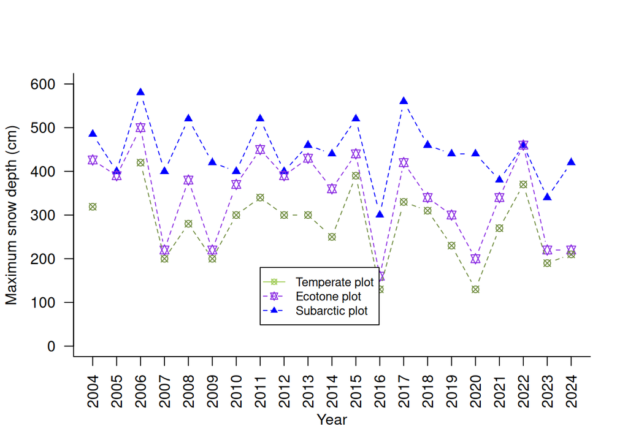

```r
Fig_snow_depth()
```

## FIGUER S2 | Changes in the annual snow cover duration (days) for each plot over time.

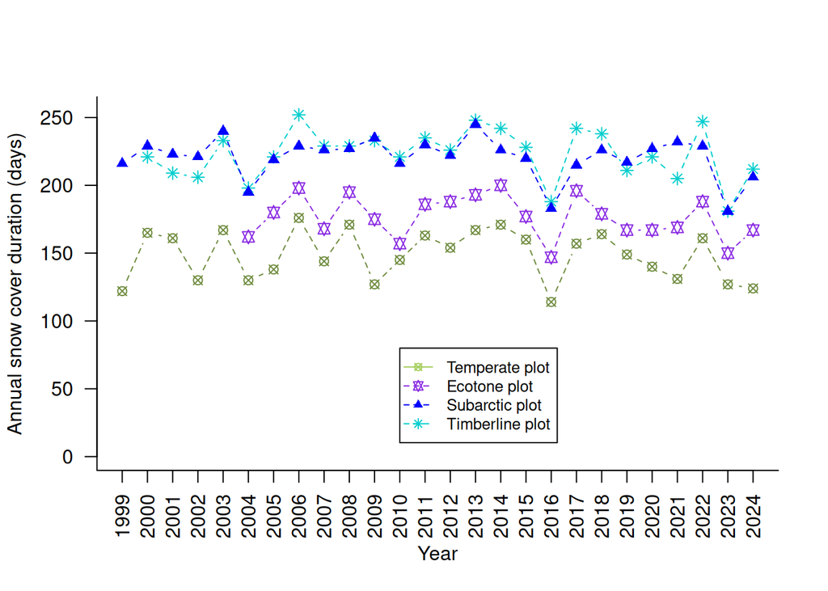

```r
Fig_snow_cover()
```

## TABLE S3 | Pearson correlation coefficients between climate variables and demographic rates(Condit et al.) of *A. mariesii*.

```r
tbl <- Table_TemperatureWIAbiesPopulation_cor()

knitr::kable(tbl) |>
  kableExtra::kable_styling(
    bootstrap_options = c("striped", "condensed"),
    font_size = 11,
    full_width = TRUE
  ) |>
  kableExtra::scroll_box(width = "100%")
```

variables

Ecotone (n=6)

WI

-0.465

0.3526

0.775

0.0702

0.022

0.9669

Tmax

-0.712

0.1125

0.957

0.0027

-0.214

0.6845

Tmin

-0.364

0.4782

0.045

0.9325

-0.589

0.2188

Tmean

-0.660

0.1539

0.599

0.2092

-0.509

0.3020

Subarctic (n=6)

WI

-0.084

0.8748

0.304

0.5581

0.076

0.8860

Tmax

-0.095

0.8583

-0.060

0.9106

-0.180

0.7323

Tmin

-0.072

0.8920

-0.263

0.6143

-0.281

0.5893

Tmean

-0.412

0.4172

0.069

0.8973

-0.568

0.2396

Timberline (n=6)

WI

-0.399

0.4328

-0.475

0.3413

-0.538

0.2711

Tmax

-0.677

0.1393

0.024

0.9641

-0.677

0.1400

Tmin

-0.075

0.8871

0.518

0.2925

0.071

0.8936

Tmean

0.030

0.9548

0.807

0.0525

0.260

0.6194

Pooled (n=18)

WI

-0.372

0.1283

0.507

0.0316

-0.082

0.7452

Tmax

-0.439

0.0682

0.611

0.0071

-0.085

0.7359

Tmin

-0.376

0.1242

0.488

0.0398

-0.107

0.6717

Tmean

-0.464

0.0526

0.432

0.0736

-0.301

0.2251